# Relatório Geral Localidades

Thiago da Costa

2024-06-13

## V-01 Localidades

Este documento destina-se a apresentar características específicas de cada localidade do município de Virtualha. Nele serão descritos os seguintes aspectos:

- Distribuição populacional geral
- Distribuição populacional por grupo de indivíduos
- Distribuição das localidades por zona
- Valor médio territorial
- Ocupação territorial
- Empregabilidade
- Incidência de localidades por tipo de natureza de atividade

Para elaboração deste documento foi utilizada exclusivamente a tabela “localidades” do banco de dados MySQL “virtualha”. Mais sobre Virtualha pode ser visto em: [PMV](https://app.netlify.com/sites/websysvirtualhabetav01/overview), e ainda o projeto completo em [GitHub.com](https://github.com/thiagodacosta85/WebSys_Virtualha).

#### Dados sobre a População

População total atual:

```
## [1] 60439
```

### Visualizações:

Gráfico `Distribuição Populacional`, exibindo em barras a maneira como a população está distribuída.

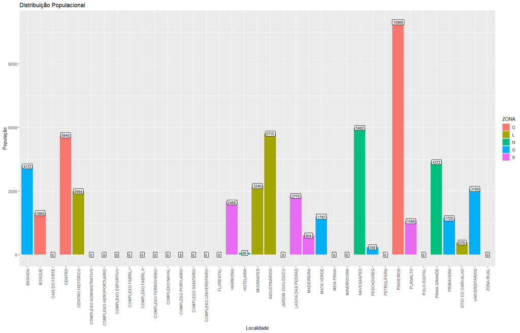

#### Distribuída da seguinte maneira:

```
## [1] "Crianças:  4124 | Adolescentes:  8650 | Jovens Adultos:  13513 | Adultos:  17062 | Idosos:  17054"
```

Gráfico `Distribuição Populacional por grupo de indivíduos` em cada uma das localidades de virtualha, excluíndo da visualização as localidades sem habitações construídas.

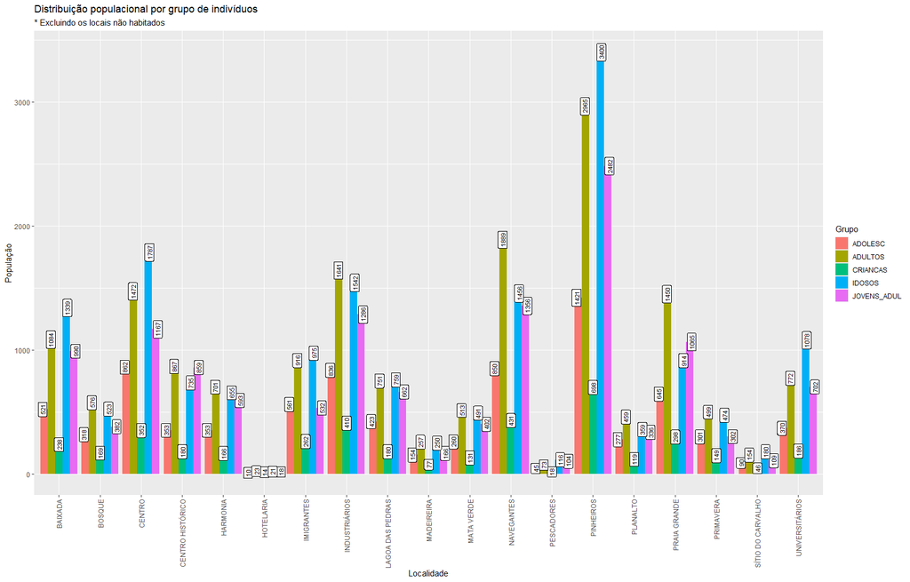

Gráfico `Distribuição das localidades por Zona` , demonstrando a quantidade de localidades em cada região geográfica de Virtualha.

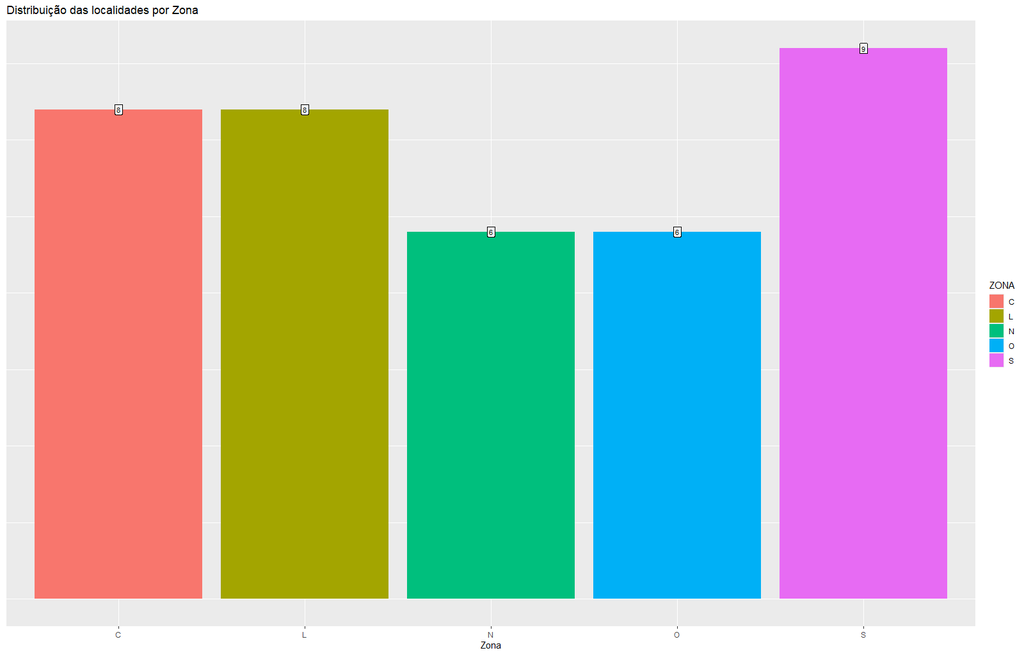

Gráfico `Valor médio dos terrenos por localidade` , gráfico com a representação em barras do valor financeiro, e situando a localidade em cores conforme legenda.

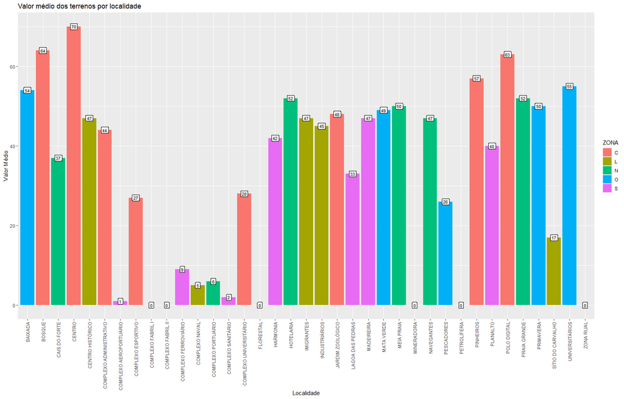

Gráfico Ocupação Territorial , gráfico com a representação em barras da ocupação territorial de Virtualha.

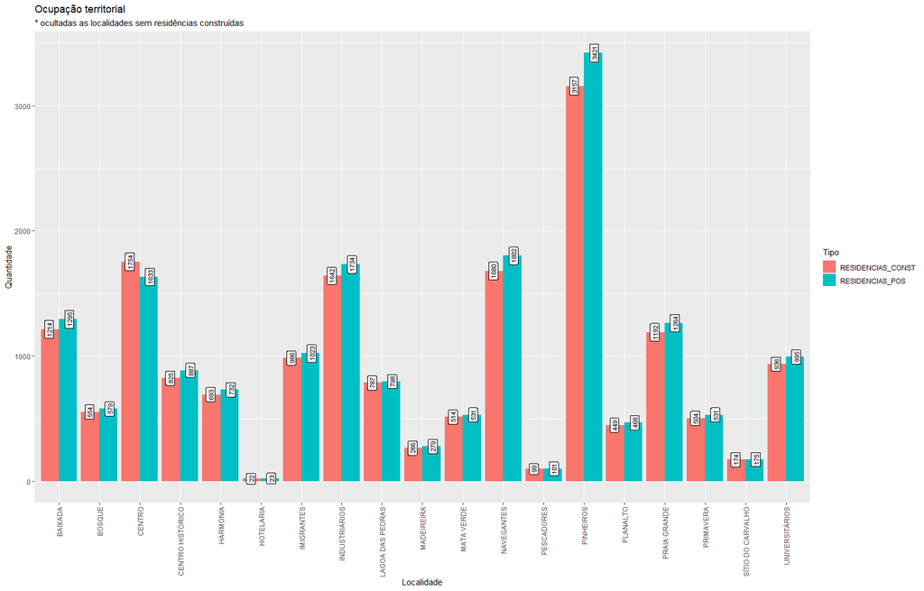

#### Dados sobre empregabilidade

```
## [1] "Atualmente o déficit de trabalhadores é de:  -4526"
```

Gráfico `Empregabilidade`, exibindo em barras por localidade como esta empregada a força de trabalho da população.

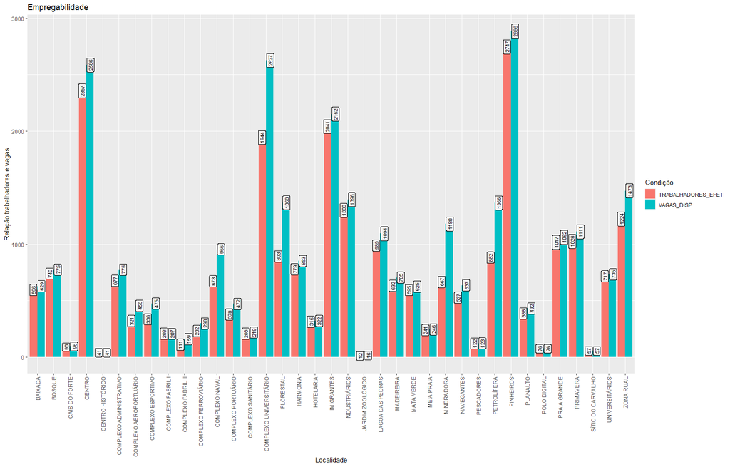

Gráfico `Incidência de localidades por atividade`, exibindo em barras a quantidade de localidades dedicada a cada uma das atividades que se realizam na cidade.

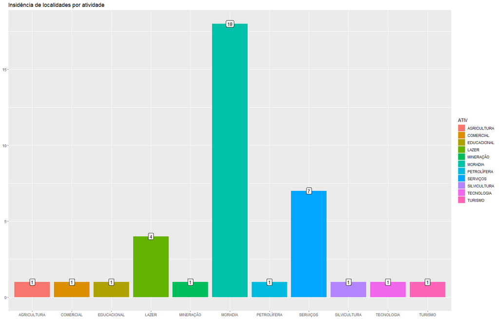